# Ted Talk

Some of the questions that can be answered with this dataset: 1. How is each TED Talk related to every other TED Talk? 2. Which are the most viewed and most favorited Talks of all time? Are they mostly the same? What does this tell us? 3. What kind of topics attract the maximum discussion and debate (in the form of comments)? 4. Which months are most popular among TED and TEDx chapters? 5. Which themes are most popular amongst TEDsters?

Read the data files

```r
library(readr)
ted <- read_csv("ted-talks/ted_main.csv")
head(ted)
```

| comments | description | duration | event | film_date | languages | main_speaker | name | num_speaker | published_date | ratings | related_talks | speaker_occupation | tags | title | url | views |
| --- | --- | --- | --- | --- | --- | --- | --- | --- | --- | --- | --- | --- | --- | --- | --- | --- |
| 4553 | Sir Ken Robinson makes an entertaining and profoundly moving case for creating an education system that nurtures (rather than undermines) creativity. | 1164 | TED2006 | 1140825600 | 60 | Ken Robinson | Ken Robinson: Do schools kill creativity? | 1 | 1151367060 | [{'id': 7, 'name': 'Funny', 'count': 19645}, {'id': 1, 'name': 'Beautiful', 'count': 4573}, {'id': 9, 'name': 'Ingenious', 'count': 6073}, {'id': 3, 'name': 'Courageous', 'count': 3253}, {'id': 11, 'n… | [{'id': 865, 'hero': 'https://pe.tedcdn.com/images/ted/172559_800x600.jpg', 'speaker': 'Ken Robinson', 'title': 'Bring on the learning revolution!', 'duration': 1008, 'slug': 'sir_ken_robinson_bring_o… | Author/educator | ['children', 'creativity', 'culture', 'dance', 'education', 'parenting', 'teaching'] | Do schools kill creativity? | https://www.ted.com/talks/ken_robinson_says_schools_kill_creativity\n | 47227110 |
| 265 | With the same humor and humanity he exuded in "An Inconvenient Truth," Al Gore spells out 15 ways that individuals can address climate change immediately, from buying a hybrid to inventing a new, hott… | 977 | TED2006 | 1140825600 | 43 | Al Gore | Al Gore: Averting the climate crisis | 1 | 1151367060 | [{'id': 7, 'name': 'Funny', 'count': 544}, {'id': 3, 'name': 'Courageous', 'count': 139}, {'id': 2, 'name': 'Confusing', 'count': 62}, {'id': 1, 'name': 'Beautiful', 'count': 58}, {'id': 21, 'name': '… | [{'id': 243, 'hero': 'https://pe.tedcdn.com/images/ted/566c14767bd62c5ff760e483c5b16cd2753328cd_2880x1620.jpg', 'speaker': 'Al Gore', 'title': 'New thinking on the climate crisis', 'duration': 1674, '… | Climate advocate | ['alternative energy', 'cars', 'climate change', 'culture', 'environment', 'global issues', 'science', 'sustainability', 'technology'] | Averting the climate crisis | https://www.ted.com/talks/al_gore_on_averting_climate_crisis\n | 3200520 |
| 124 | New York Times columnist David Pogue takes aim at technologys worst interface-design offenders, and provides encouraging examples of products that get it right. To funny things up, he bursts into song… | 1286 | TED2006 | 1140739200 | 26 | David Pogue | David Pogue: Simplicity sells | 1 | 1151367060 | [{'id': 7, 'name': 'Funny', 'count': 964}, {'id': 3, 'name': 'Courageous', 'count': 45}, {'id': 9, 'name': 'Ingenious', 'count': 183}, {'id': 1, 'name': 'Beautiful', 'count': 60}, {'id': 21, 'name': '… | [{'id': 1725, 'hero': 'https://pe.tedcdn.com/images/ted/b7f415a054cc0a2bfdd90d0ad5a7f64cf060150d_1600x1200.jpg', 'speaker': 'David Pogue', 'title': '10 top time-saving tech tips', 'duration': 344, 'sl… | Technology columnist | ['computers', 'entertainment', 'interface design', 'media', 'music', 'performance', 'simplicity', 'software', 'technology'] | Simplicity sells | https://www.ted.com/talks/david_pogue_says_simplicity_sells\n | 1636292 |
| 200 | In an emotionally charged talk, MacArthur-winning activist Majora Carter details her fight for environmental justice in the South Bronx -- and shows how minority neighborhoods suffer most from flawed … | 1116 | TED2006 | 1140912000 | 35 | Majora Carter | Majora Carter: Greening the ghetto | 1 | 1151367060 | [{'id': 3, 'name': 'Courageous', 'count': 760}, {'id': 1, 'name': 'Beautiful', 'count': 291}, {'id': 2, 'name': 'Confusing', 'count': 32}, {'id': 7, 'name': 'Funny', 'count': 59}, {'id': 9, 'name': 'I… | [{'id': 1041, 'hero': 'https://pe.tedcdn.com/images/ted/96c703bb13a2e9c2d351a5e6b52390bc35eaad06_800x600.jpg', 'speaker': 'Majora Carter', 'title': '3 stories of local eco-entrepreneurship', 'duration… | Activist for environmental justice | ['MacArthur grant', 'activism', 'business', 'cities', 'environment', 'green', 'inequality', 'politics', 'pollution'] | Greening the ghetto | https://www.ted.com/talks/majora_carter_s_tale_of_urban_renewal\n | 1697550 |
| 593 | You've never seen data presented like this. With the drama and urgency of a sportscaster, statistics guru Hans Rosling debunks myths about the so-called "developing world." | 1190 | TED2006 | 1140566400 | 48 | Hans Rosling | Hans Rosling: The best stats you've ever seen | 1 | 1151440680 | [{'id': 9, 'name': 'Ingenious', 'count': 3202}, {'id': 7, 'name': 'Funny', 'count': 1390}, {'id': 1, 'name': 'Beautiful', 'count': 942}, {'id': 3, 'name': 'Courageous', 'count': 318}, {'id': 11, 'name… | [{'id': 2056, 'hero': 'https://pe.tedcdn.com/images/ted/afc9b259845ec1b543419871e10753d4d9044fda_2400x1800.jpg', 'speaker': 'Talithia Williams', 'title': "Own your body's data", 'duration': 1023, 'slu… | Global health expert; data visionary | ['Africa', 'Asia', 'Google', 'demo', 'economics', 'global development', 'global issues', 'health', 'math', 'statistics', 'visualizations'] | The best stats you've ever seen | https://www.ted.com/talks/hans_rosling_shows_the_best_stats_you_ve_ever_seen\n | 12005869 |
| 672 | Tony Robbins discusses the "invisible forces" that motivate everyone's actions -- and high-fives Al Gore in the front row. | 1305 | TED2006 | 1138838400 | 36 | Tony Robbins | Tony Robbins: Why we do what we do | 1 | 1151440680 | [{'id': 7, 'name': 'Funny', 'count': 1102}, {'id': 3, 'name': 'Courageous', 'count': 721}, {'id': 21, 'name': 'Unconvincing', 'count': 377}, {'id': 2, 'name': 'Confusing', 'count': 301}, {'id': 1, 'na… | [{'id': 229, 'hero': 'https://pe.tedcdn.com/images/ted/eefe30d20338d800bdc70a09dc0f6007e7355a74_2880x1620.jpg', 'speaker': 'Jill Bolte Taylor', 'title': 'My stroke of insight', 'duration': 1099, 'slug… | Life coach; expert in leadership psychology | ['business', 'culture', 'entertainment', 'goal-setting', 'motivation', 'potential', 'psychology'] | Why we do what we do | https://www.ted.com/talks/tony_robbins_asks_why_we_do_what_we_do\n | 20685401 |

```r
transcript <- read_csv("ted-talks/transcripts.csv")
head(transcript)
```

| transcript | url |
| --- | --- |
| Good morning. How are you?(Laughter)It's been great, hasn't it? I've been blown away by the whole thing. In fact, I'm leaving.(Laughter)There have been three themes running through the conference whic… | https://www.ted.com/talks/ken_robinson_says_schools_kill_creativity\n |
| Thank you so much, Chris. And it's truly a great honor to have the opportunity to come to this stage twice; I'm extremely grateful. I have been blown away by this conference, and I want to thank all o… | https://www.ted.com/talks/al_gore_on_averting_climate_crisis\n |
| (Music: "The Sound of Silence," Simon & Garfunkel)Hello voice mail, my old friend.(Laughter)I've called for tech support again. I ignored my boss's warning. I called on a Monday morning. Now it's even… | https://www.ted.com/talks/david_pogue_says_simplicity_sells\n |
| If you're here today and I'm very happy that you are you've all heard about how sustainable development will save us from ourselves. However, when we're not at TED, we are often told that a real susta… | https://www.ted.com/talks/majora_carter_s_tale_of_urban_renewal\n |
| About 10 years ago, I took on the task to teach global development to Swedish undergraduate students. That was after having spent about 20 years together with African institutions studying hunger in A… | https://www.ted.com/talks/hans_rosling_shows_the_best_stats_you_ve_ever_seen\n |
| Thank you. I have to tell you I'm both challenged and excited. My excitement is: I get a chance to give something back. My challenge is: the shortest seminar I usually do is 50 hours.(Laughter)I'm not… | https://www.ted.com/talks/tony_robbins_asks_why_we_do_what_we_do\n |

See the information of both datasets

```r
summary(ted)
```

```
    comments      description           duration         event             film_date           languages
 Min.   :   2.0   Length:2550        Min.   : 135.0   Length:2550        Min.   :7.465e+07   Min.   : 0.00
 1st Qu.:  63.0   Class :character   1st Qu.: 577.0   Class :character   1st Qu.:1.257e+09   1st Qu.:23.00
 Median : 118.0   Mode  :character   Median : 848.0   Mode  :character   Median :1.333e+09   Median :28.00
 Mean   : 191.6                      Mean   : 826.5                      Mean   :1.322e+09   Mean   :27.33
 3rd Qu.: 221.8                      3rd Qu.:1046.8                      3rd Qu.:1.413e+09   3rd Qu.:33.00
 Max.   :6404.0                      Max.   :5256.0                      Max.   :1.504e+09   Max.   :72.00
 main_speaker           name            num_speaker    published_date        ratings          related_talks
 Length:2550        Length:2550        Min.   :1.000   Min.   :1.151e+09   Length:2550        Length:2550
 Class :character   Class :character   1st Qu.:1.000   1st Qu.:1.268e+09   Class :character   Class :character
 Mode  :character   Mode  :character   Median :1.000   Median :1.341e+09   Mode  :character   Mode  :character
                                       Mean   :1.028   Mean   :1.344e+09
                                       3rd Qu.:1.000   3rd Qu.:1.423e+09
                                       Max.   :5.000   Max.   :1.506e+09
 speaker_occupation     tags              title               url                views
 Length:2550        Length:2550        Length:2550        Length:2550        Min.   :   50443
 Class :character   Class :character   Class :character   Class :character   1st Qu.:  755793
 Mode  :character   Mode  :character   Mode  :character   Mode  :character   Median : 1124524
                                                                             Mean   : 1698297
                                                                             3rd Qu.: 1700760
                                                                             Max.   :47227110
```

```r
summary(transcript)
```

```
  transcript            url
 Length:2467        Length:2467
 Class :character   Class :character
 Mode  :character   Mode  :character
```

Check the dimensions of the data

```r
dim(ted)
```

```
[1] 2550   17
```

```r
dim(transcript)
```

```
[1] 2467    2
```

Let’s change the UNIX timestamps to human readable date

```r
library(anytime)
ted$film_date <- anydate(ted$film_date)
ted$published_date <- anydate(ted$published_date)
```

Exploratory Data Analysis - Which talks are most and least viewed?

Which talks are most and least viewed?

```r
library(dplyr)
ten_talks <- arrange(ted, views)
keeps <- c("title", "main_speaker", "views", "speaker_occupation", "film_date")
ten_talks <- subset(ten_talks, select = c("title", "main_speaker", "views", "speaker_occupation", "film_date"))
last_10_talks <- ten_talks[0:10,]
last_10_talks
```

| title | main_speaker | views | speaker_occupation | film_date |
| --- | --- | --- | --- | --- |
| Stories of Haiti | Edwidge Danticat | 50443 | Author | 2004-10-13 |
| The debut of the British Paraorchestra | Charles Hazlewood + British Paraorchestra | 66668 | Contemporary music ensemble | 2011-11-22 |
| "Kounandi" | Rokia Traore | 82488 | Singer-songwriter | 2007-06-06 |
| The early birdwatchers | Tim Birkhead | 112321 | Ornithologist | 2009-09-18 |
| Let's bridge the digital divide! | Aleph Molinari | 115346 | Economist, techno-activist | 2011-08-06 |
| Beethoven the businessman | Jos Bowen | 117756 | Professor of music | 2011-12-03 |
| Deaf in the military | Keith Nolan | 120274 | Teacher | 2011-04-23 |
| Don't misrepresent Africa | Leslie Dodson | 121186 | Reporter | 2011-09-24 |
| Change our culture, change our world | Nate Garvis | 125050 | Civic thought leader | 2010-10-13 |
| Beautiful artificial limbs | Scott Summit | 132199 | Industrial Designer | 2011-11-19 |

```r
ten_talks <- arrange(ted, desc(views))
ten_talks <- subset(ten_talks, select = c("title", "main_speaker", "views", "speaker_occupation", "film_date"))
top_10_talks <- ten_talks[0:10,]
top_10_talks
```

| title | main_speaker | views | speaker_occupation | film_date |
| --- | --- | --- | --- | --- |
| Do schools kill creativity? | Ken Robinson | 47227110 | Author/educator | 2006-02-25 |
| Your body language may shape who you are | Amy Cuddy | 43155405 | Social psychologist | 2012-06-26 |
| How great leaders inspire action | Simon Sinek | 34309432 | Leadership expert | 2009-09-17 |
| The power of vulnerability | Bren Brown | 31168150 | Vulnerability researcher | 2010-06-06 |
| 10 things you didn't know about orgasm | Mary Roach | 22270883 | Writer | 2009-02-06 |
| How to speak so that people want to listen | Julian Treasure | 21594632 | Sound consultant | 2013-06-10 |
| My stroke of insight | Jill Bolte Taylor | 21190883 | Neuroanatomist | 2008-02-27 |
| Why we do what we do | Tony Robbins | 20685401 | Life coach; expert in leadership psychology | 2006-02-02 |
| This is what happens when you reply to spam email | James Veitch | 20475972 | Comedian and writer | 2015-12-08 |
| Looks aren't everything. Believe me, I'm a model. | Cameron Russell | 19787465 | Model | 2012-10-27 |

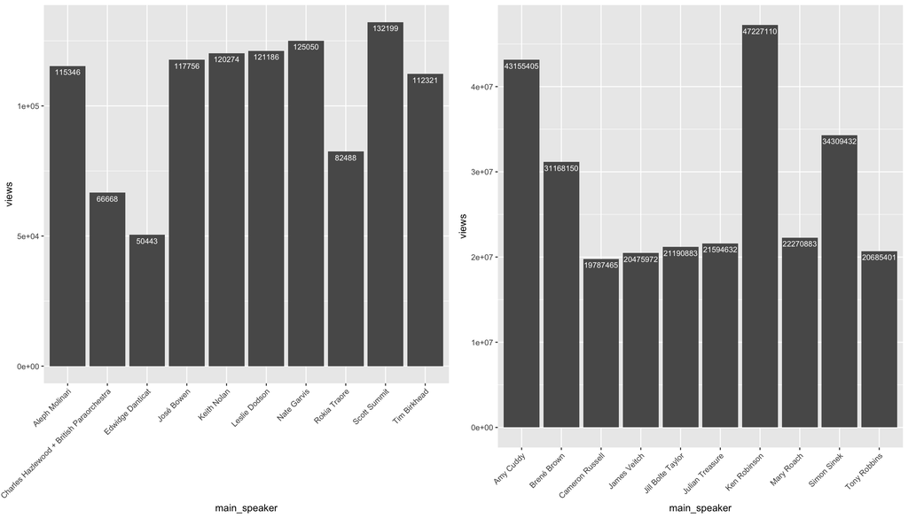

Distribution of Views

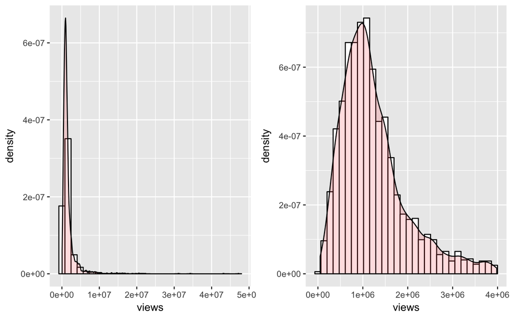

```r
ted_small <- subset(ted, views < 0.4e7)
p3 <- ggplot(ted, aes(x=views)) +
 geom_histogram(aes(y=..density..), colour="black", fill="white")+
 geom_density(alpha=.2, fill="#FF6666")
p4 <- ggplot(ted_small, aes(x=views)) +
  geom_histogram(aes(y=..density..), colour="black", fill="white")+
  geom_density(alpha=.2, fill="#FF6666")
multiplot(p3, p4, cols=2)
```

```r
library(Hmisc)
describe(ted$views)
```

```
ted$views
       n  missing distinct     Info     Mean      Gmd      .05      .10      .25      .50      .75      .90      .95
    2550        0     2550        1  1698297  1562903   361142   484265   755793  1124524  1700760  3051913  4557041

lowest :    50443    66668    82488   112321   115346, highest: 22270883 31168150 34309432 43155405 47227110
```

Comments Let’s analyze comments on the talks

```r
describe(ted$comments)
```

```
ted$comments
       n  missing distinct     Info     Mean      Gmd      .05      .10      .25      .50      .75      .90      .95
    2550        0      559        1    191.6    197.6     24.0     35.9     63.0    118.0    221.8    393.1    586.1

lowest :    2    3    5    6    7, highest: 2673 2877 3356 4553 6404
```

```r
sd(ted$comments)
```

```
[1] 282.3152
```

Observations - On average, there are 191.5 comments on every TED Talk. Assuming the comments are constructive criticism, we can conclude that the TED Online Community is highly involved in discussions revolving TED Talks. - There is a huge standard deviation associated with the comments. In fact, it is even larger than the mean suggesting that the measures may be sensitive to outliers. We shall plot this to check the nature of the distribution. - The minimum number of comments on a talk is 2 and the maximum is 6404. The range is 6402.. The minimum number, though, may be as a result of the talk being posted extremely recently.

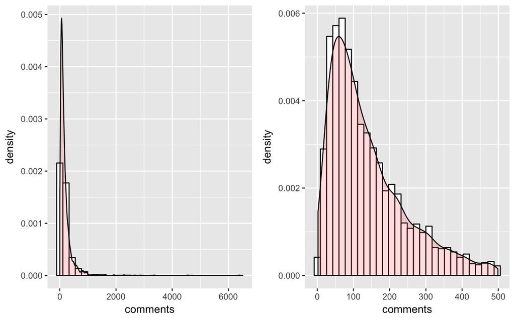

```r
ted_small <- subset(ted, comments < 500)
p5 <- ggplot(ted, aes(x=comments)) +
 geom_histogram(aes(y=..density..), colour="black", fill="white")+
 geom_density(alpha=.2, fill="#FF6666")
p6 <- ggplot(ted_small, aes(x=comments)) +
  geom_histogram(aes(y=..density..), colour="black", fill="white")+
  geom_density(alpha=.2, fill="#FF6666")
multiplot(p5, p6, cols=2)
```

From the plot above, we can see that the bulk of the talks have fewer than 500 comments. This clearly suggests that the mean obtained above has been heavily influenced by outliers. This is possible because the number of samples is only 2550 talks.

Another question that I am interested in is if the number of views is correlated with the number of comments. We should think that this is the case as more popular videos tend to have more comments. Let us find out.

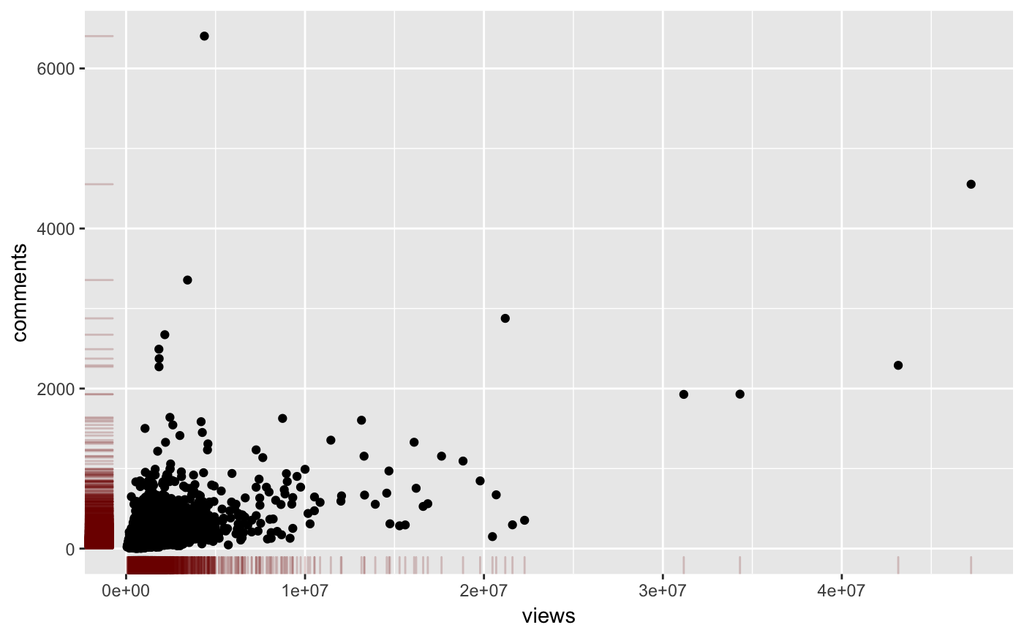

```r
scatter1 <- qplot(views,comments, data=ted)  +
         scale_x_continuous(limits=c(min(ted$views),max(ted$views))) +
         scale_y_continuous(limits=c(min(ted$comments),max(ted$comments))) +
         geom_rug(col=rgb(.5,0,0,alpha=.2))
scatter1
```

```r
vc_cor <- cor(ted$views, ted$comments)
print("Correlation between Views and Comments")
```

```
[1] "Correlation between Views and Comments"
```

```r
vc_cor
```

```
[1] 0.5309387
```

As the scatterplot and the correlation matrix show, the pearson coefficient is slightly more than 0.5. This suggests a medium to strong correlation between the two quantities. This result was pretty expected as mentioned above. Let us now check the number of views and comments on the 10 most commented TED Talks of all time.

```r
ten_talks <- arrange(ted, comments)
keeps <- c("title", "main_speaker", "views", "comments")
ten_talks <- subset(ten_talks, select = keeps)
last_10_talks <- ten_talks[0:10,]
last_10_talks
```

| title | main_speaker | views | comments |
| --- | --- | --- | --- |
| What it feels like to see Earth from space | Benjamin Grant | 646174 | 2 |
| The stories behind The New Yorker's iconic covers | Franoise Mouly | 839040 | 3 |
| How your pictures can help reclaim lost history | Chance Coughenour | 539207 | 3 |
| Living sculptures that stand for history's truths | Sethembile Msezane | 542088 | 3 |
| "Turceasca" | Silk Road Ensemble | 640734 | 5 |
| "St. James Infirmary Blues" | Silk Road Ensemble + Rhiannon Giddens | 820295 | 6 |
| Smelfies, and other experiments in synthetic biology | Ani Liu | 760537 | 6 |
| A dance to honor Mother Earth | Jon Boogz and Lil Buck | 182975 | 6 |
| The most Martian place on Earth | Armando Azua-Bustos | 417470 | 6 |
| A simple new blood test that can catch cancer early | Jimmy Lin | 1005506 | 7 |

```r
ten_talks <- arrange(ted, desc(comments))
ten_talks <- subset(ten_talks, select = keeps)
top_10_talks <- ten_talks[0:10,]
top_10_talks
```

| title | main_speaker | views | comments |
| --- | --- | --- | --- |
| Militant atheism | Richard Dawkins | 4374792 | 6404 |
| Do schools kill creativity? | Ken Robinson | 47227110 | 4553 |
| Science can answer moral questions | Sam Harris | 3433437 | 3356 |
| My stroke of insight | Jill Bolte Taylor | 21190883 | 2877 |
| How do you explain consciousness? | David Chalmers | 2162764 | 2673 |
| Taking imagination seriously | Janet Echelman | 1832930 | 2492 |
| On reading the Koran | Lesley Hazleton | 1847256 | 2374 |
| Your body language may shape who you are | Amy Cuddy | 43155405 | 2290 |
| The danger of science denial | Michael Specter | 1838628 | 2272 |
| How great leaders inspire action | Simon Sinek | 34309432 | 1930 |

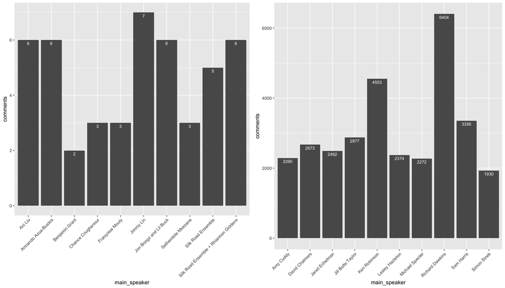

As can be seen above, Richard Dawkins’ talk on Militant Atheism’ generated the greatest amount of discussion and opinions despite having significantly lesser views than Ken Robinson’s talk, which is second in the list. This raises some interesting questions.

Which talks tend to attract the largest amount of discussion?

To answer this question, we will define a new feature discussion quotient which is simply the ratio of the number of comments to the number of views. We will then check which talks have the largest discussion quotient.

```r
ted$dis_quo <- ted$comments/ted$views
ten_talks <- arrange(ted, dis_quo)
keeps <- c("title", "main_speaker", "views", "comments", "dis_quo")
ten_talks <- subset(ten_talks, select = keeps)
last_10_talks <- ten_talks[0:10,]
last_10_talks
```

| title | main_speaker | views | comments | dis_quo |
| --- | --- | --- | --- | --- |
| What it feels like to see Earth from space | Benjamin Grant | 646174 | 2 | 3.095142e-06 |
| The stories behind The New Yorker's iconic covers | Franoise Mouly | 839040 | 3 | 3.575515e-06 |
| Living sculptures that stand for history's truths | Sethembile Msezane | 542088 | 3 | 5.534157e-06 |
| How your pictures can help reclaim lost history | Chance Coughenour | 539207 | 3 | 5.563726e-06 |
| A simple new blood test that can catch cancer early | Jimmy Lin | 1005506 | 7 | 6.961669e-06 |
| "St. James Infirmary Blues" | Silk Road Ensemble + Rhiannon Giddens | 820295 | 6 | 7.314442e-06 |
| This is what happens when you reply to spam email | James Veitch | 20475972 | 150 | 7.325660e-06 |
| "Turceasca" | Silk Road Ensemble | 640734 | 5 | 7.803550e-06 |
| Smelfies, and other experiments in synthetic biology | Ani Liu | 760537 | 6 | 7.889163e-06 |
| The agony of trying to unsubscribe | James Veitch | 5711833 | 46 | 8.053457e-06 |

```r
ten_talks <- arrange(ted, desc(dis_quo))
ten_talks <- subset(ten_talks, select = keeps)
top_10_talks <- ten_talks[0:10,]
top_10_talks
```

| title | main_speaker | views | comments | dis_quo |
| --- | --- | --- | --- | --- |
| The case for same-sex marriage | Diane J. Savino | 292395 | 649 | 0.002219600 |
| E-voting without fraud | David Bismark | 543551 | 834 | 0.001534355 |
| Militant atheism | Richard Dawkins | 4374792 | 6404 | 0.001463841 |
| Inside a school for suicide bombers | Sharmeen Obaid-Chinoy | 1057238 | 1502 | 0.001420683 |
| Taking imagination seriously | Janet Echelman | 1832930 | 2492 | 0.001359572 |
| On reading the Koran | Lesley Hazleton | 1847256 | 2374 | 0.001285149 |
| Curating humanity's heritage | Elizabeth Lindsey | 439180 | 555 | 0.001263719 |
| How do you explain consciousness? | David Chalmers | 2162764 | 2673 | 0.001235918 |
| The danger of science denial | Michael Specter | 1838628 | 2272 | 0.001235704 |
| Dance to change the world | Mallika Sarabhai | 481834 | 595 | 0.001234865 |

This analysis has actually raised extremely interesting insights. Half of the talks in the top 10 are on the lines of Faith and Religion. I suspect science and religion is still a very hotly debated topic even in the 21st century. We shall come back to this hypothesis in a later section.

The most discusses talk, though, is The Case for Same Sex Marriage (which has religious undertones). This is not that surprising considering the amount of debate the topic caused back in 2009 (the time the talk was filmed).

Analyzing TED talks by the month and the year

TED (especially TEDx) Talks tend to occur all throughout the year. Is there a hot month as far as TED is concerned? In other words, how are the talks distributed throughout the months since its inception? Let us find out.

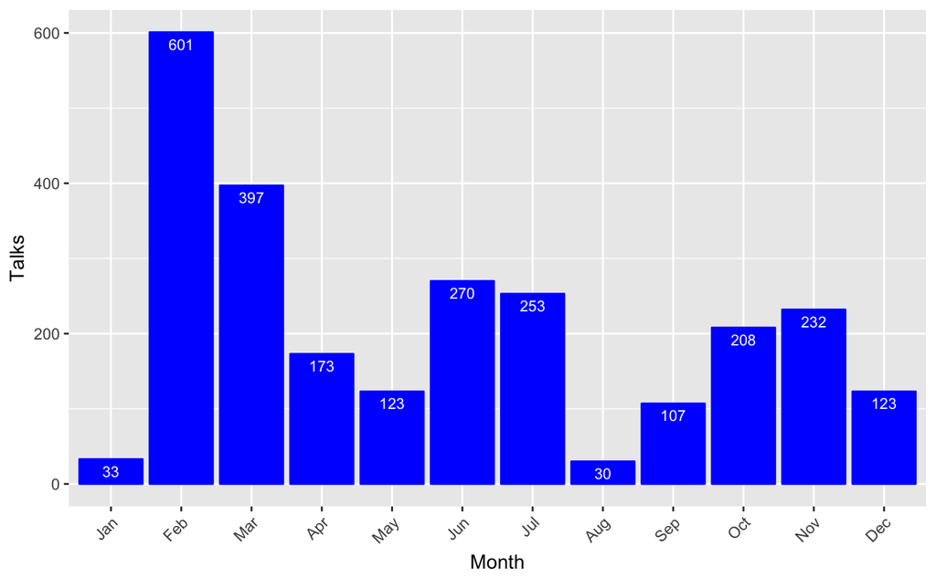

```r
ted$filming_month <- as.numeric(format(ted$film_date, format= "%m"))
ted$filming_year <- as.numeric(format(ted$film_date, format = "%Y"))
month_df <- as.data.frame(table(ted$filming_month))
colnames(month_df) <- c("Month", "Talks")
month_df$Month <- c("Jan", "Feb", "Mar", "Apr", "May", "Jun", "Jul", "Aug", "Sep", "Oct", "Nov", "Dec")
#Turn your 'Month' column into a character vector
month_df$Month <- as.character(month_df$Month)
#Then turn it back into an ordered factor
month_df$Month <- factor(month_df$Month, levels=unique(month_df$Month))
p8 <- ggplot(data = month_df, aes(Month, Talks)) +
      geom_bar(position = "dodge", stat = "identity", color = "blue", fill="blue") +
      geom_text(aes(label = Talks), vjust = 1.6, color = "white", size = 3) +
      tilt_theme
p8
```

February is clearly the most popular month for TED Conferences whereas August and January are the least popular. February’s popularity is largely due to the fact that the official TED Conferences are held in February. Let us check the distribution for TEDx talks only.

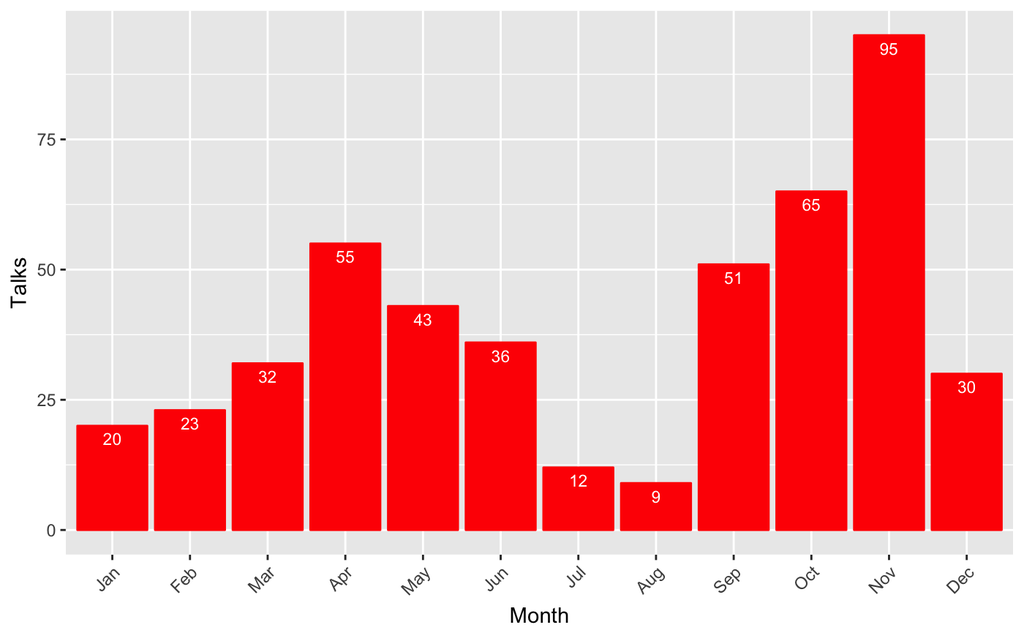

```r
tedx <- filter(ted, grepl("TEDx", ted$event, fixed = TRUE))
month_df <- as.data.frame(table(tedx$filming_month))
colnames(month_df) <- c("Month", "Talks")
month_df$Month <- c("Jan", "Feb", "Mar", "Apr", "May", "Jun", "Jul", "Aug", "Sep", "Oct", "Nov", "Dec")
#Turn your 'Month' column into a character vector
month_df$Month <- as.character(month_df$Month)
#Then turn it back into an ordered factor
month_df$Month <- factor(month_df$Month, levels=unique(month_df$Month))
p9 <- ggplot(data = month_df, aes(Month, Talks)) +
      geom_bar(position = "dodge", stat = "identity", color = "red", fill="red") +
      geom_text(aes(label = Talks), vjust = 1.6, color = "white", size = 3) +
      tilt_theme
p9
```

As far as TEDx talks are concerned, November is the most popular month. However, we cannot take this result at face value as very few of the TEDx talks are actually uploaded to the TED website and therefore, it is entirely possible that the sample in our dataset is not at all representative of all TEDx talks. A slightly more accurate statement would be that the most popular TEDx talks take place the most in October and November.

The next question I’m interested in is the most popular days for conducting TED and TEDx conferences. The tools applied are very sensible to the procedure applied for months.

```r
ted$film_weekday <- weekdays(as.Date(ted$film_date))
weekday_df <- as.data.frame(table(ted$film_weekday))
weekday_df
```

| Var1 | Freq |
| --- | --- |
| Friday | 385 |
| Monday | 306 |
| Saturday | 338 |
| Sunday | 110 |
| Thursday | 551 |
| Tuesday | 326 |
| Wednesday | 534 |

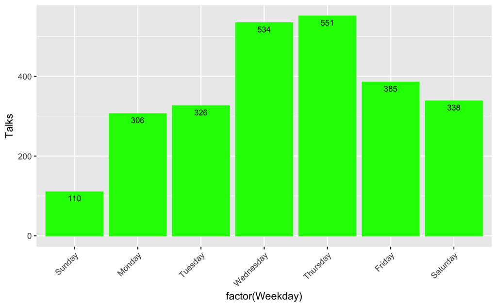

```r
colnames(weekday_df) <- c("Weekday", "Talks")
weekday_df <- weekday_df[c(4,2,6,7,5,1,3),]
#Turn your 'Month' column into a character vector
weekday_df$Weekday <- as.character(weekday_df$Weekday)
#Then turn it back into an ordered factor
weekday_df$Weekday <- factor(weekday_df$Weekday, levels=unique(weekday_df$Weekday))
p10 <- ggplot(data = weekday_df, aes(factor(Weekday), Talks)) +
      geom_bar(position = "dodge", stat = "identity", color = "green", fill="green") +
      geom_text(aes(label = Talks), vjust = 1.6, color = "black", size = 3) +
      tilt_theme
p10
```

The distribution of days is almost a bell curve with Wednesday and Thursday being the most popular days and Sunday being the least popular. This is pretty interesting because I was of the opinion that most TED Conferences would happen sometime in the weekend.

Let us now visualize the number of TED talks through the years and check if our hunch that they have grown significantly is indeed true.

```r
year_df <- as.data.frame(table(ted$filming_year))
year_df
```

| Var1 | Freq |
| --- | --- |
| 1972 | 1 |
| 1983 | 1 |
| 1984 | 1 |
| 1990 | 1 |
| 1991 | 1 |
| 1994 | 1 |
| 1998 | 6 |
| 2001 | 5 |
| 2002 | 27 |
| 2003 | 33 |

[output cut: 14 more lines]

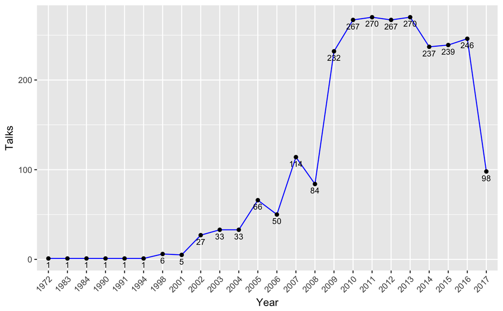

```r
colnames(year_df) <- c("Year", "Talks")
#Turn your 'Month' column into a character vector
#month_df$Month <- as.character(month_df$Month)
#Then turn it back into an ordered factor
#month_df$Month <- factor(month_df$Month, levels=unique(month_df$Month))
p11 <- ggplot(data = year_df, aes(Year, Talks, group = 1)) +
      geom_line(color = "blue") +
      geom_point() +
      geom_text(aes(label = Talks), vjust = 1.6, color = "black", size = 3) +
      tilt_theme
p11
```

Obervations - As expected, the number of TED Talks have gradually increased over the years since its inception in 1984. - There was a sharp increase in the number if talks in 2009. It might be interesting to know the reasons behind 2009 being the tipping point where the number of talks increased more than twofold. - The number of talks have been pretty much constant since 2009.

Finally, to put it all together, let us construct a heat map that shows us the number of talks by month and year. This will give us a good summary of the distribution of talks.

```
Ignoring unknown aesthetics: fill
```

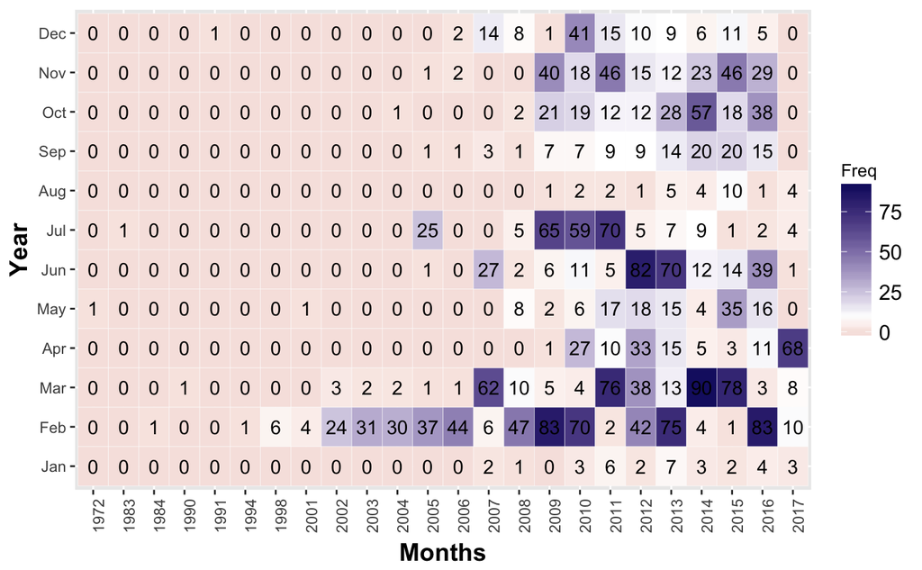

```r
keeps <- c("filming_month", "filming_year")
heatmap_df <- ted %>% subset(select = keeps) %>% arrange(filming_year)
heatmap_df <- as.data.frame(table(heatmap_df))
heatmap_df$filming_month <- month.abb[heatmap_df$filming_month]
heatmap_df$filming_month <- as.character(heatmap_df$filming_month)
heatmap_df$filming_month <- factor(heatmap_df$filming_month, levels=unique(month_df$Month))
#heatmap_df
ggplot(heatmap_df, aes(filming_year, factor(filming_month))) +
  geom_tile(aes(fill = Freq), color = "white") +
  geom_text(aes(fill = heatmap_df$Freq, label = heatmap_df$Freq)) +
  scale_fill_gradient2(low = "darkred",
                       mid = "white",
                       high = "midnightblue",
                       midpoint = round(mean(heatmap_df$Freq))) +
  ylab("Year") +
  xlab("Months") +
  theme(legend.title = element_text(size = 10),
        legend.text = element_text(size = 12),
        plot.title = element_text(size=16),
        axis.title=element_text(size=14,face="bold"),
        axis.text.x = element_text(angle = 90, hjust = 1)) +
  labs(fill = "Freq")
```

Ted Speakers

In this section, we will try and gain insight about all the amazing speakers who have managed to inspire millions of people through their talks on the TED Platform. The first question we shall ask in this section is who are the most popular TED Speakers. That is, which speakers have given the most number of TED Talks.

```r
speaker_df <- as.data.frame(table(ted$main_speaker))
speaker_df <- arrange(speaker_df, desc(Freq))
speaker_df
```

| Var1 | Freq |
| --- | --- |
| Hans Rosling | 9 |
| Juan Enriquez | 7 |
| Marco Tempest | 6 |
| Rives | 6 |
| Bill Gates | 5 |
| Clay Shirky | 5 |
| Dan Ariely | 5 |
| Jacqueline Novogratz | 5 |
| Julian Treasure | 5 |
| Nicholas Negroponte | 5 |

[output cut: 990 more lines]

Which occupation should you choose if you want to become a TED Speaker? Let us have a look what kind of people TED is most interested in inviting to its events.

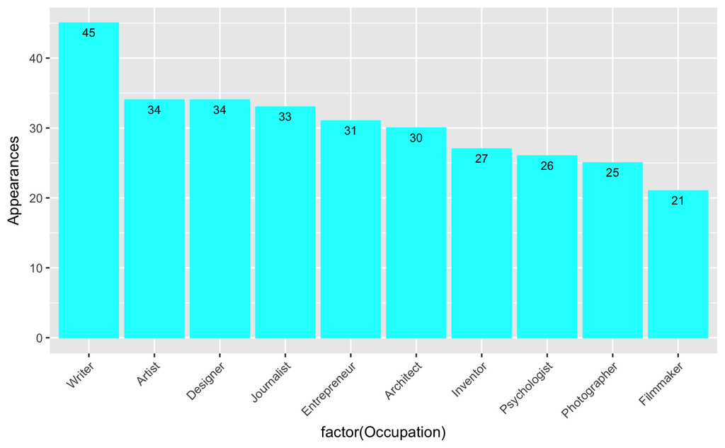

```r
occupation_df <- as.data.frame(table(ted$speaker_occupation))
occupation_df <- arrange(occupation_df, desc(Freq))
occupation_df <- head(occupation_df, 10)
colnames(occupation_df) <- c("Occupation", "Appearances")
occupation_df$Occupation <- as.character(occupation_df$Occupation)
occupation_df$Occupation <- factor(occupation_df$Occupation, levels=occupation_df$Occupation)
p12 <- ggplot(data = occupation_df, aes(factor(Occupation), Appearances)) +
      geom_bar(position = "dodge", stat = "identity", color = "cyan", fill="cyan") +
      geom_text(aes(label = Appearances), vjust = 1.6, color = "black", size = 3) +
      tilt_theme
p12
```

Do some professions tend to attract a larger number of viewers? Do answer this question let us visualise the relationship between the top 10 most popular professions and the views that garnered in the form of a box plot.

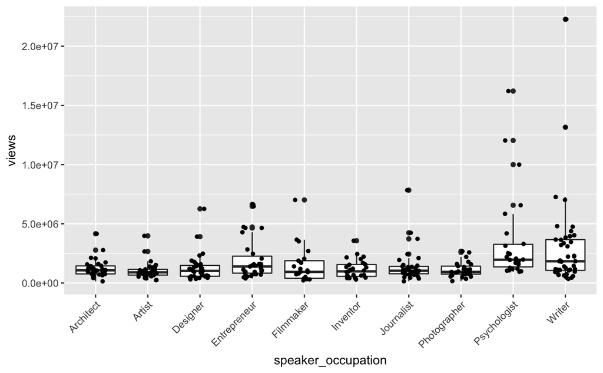

```r
top_occupation_views <- filter(ted, ted$speaker_occupation %in% occupation_df$Occupation)
p13 <- ggplot(top_occupation_views, aes(x=speaker_occupation, y=views)) +
  geom_boxplot() +
  geom_jitter(shape=16, position=position_jitter(0.2)) +
  tilt_theme
p13
```

On average, out of the top 10 most popular professions, Psychologists tend to garner the most views. Writers have the greatest range of views between the first and the third quartile..

Finally, let us check the number of talks which have had more than one speaker.

```r
speaker_count <- table(ted$num_speaker)
speaker_count
```

```
   1    2    3    4    5
2492   49    5    3    1
```

Almost every talk has just one speaker. There are close to 50 talks where two people shared the stage. The maximum number of speakers to share a single stage was 5. I suspect this was a dance performance. Let’s have a look.

```r
filter(ted, ted$num_speaker==5)
```

| comments | description | duration | event | film_date | languages | main_speaker | name | num_speaker | published_date | ratings | related_talks | speaker_occupation | tags | title | url | views | dis_quo | filming_month | filming_year | film_weekday |
| --- | --- | --- | --- | --- | --- | --- | --- | --- | --- | --- | --- | --- | --- | --- | --- | --- | --- | --- | --- | --- |
| 6 | Movement artists Jon Boogz and Lil Buck debut "Honor thy mother," a delicate, powerful performance of spoken word, violin and dance that draws on the tormented relationship between nature and humanity… | 575 | TED2017 | 2017-04-24 | 12 | Jon Boogz and Lil Buck | Jon Boogz and Lil Buck: A dance to honor Mother Earth | 5 | 2017-08-11 | [{'id': 1, 'name': 'Beautiful', 'count': 84}, {'id': 2, 'name': 'Confusing', 'count': 3}, {'id': 26, 'name': 'Obnoxious', 'count': 2}, {'id': 10, 'name': 'Inspiring', 'count': 23}, {'id': 22, 'name': … | [{'id': 2589, 'hero': 'https://pe.tedcdn.com/images/ted/7e8a2533ffe6a7a79ff0c4e1e166881cc3fddc4e_2880x1620.jpg', 'speaker': 'Camille A. Brown', 'title': 'A visual history of social dance in 25 moves',… | Movement artist | ['art', 'creativity', 'dance', 'performance', 'performance art'] | A dance to honor Mother Earth | https://www.ted.com/talks/jon_boogz_and_lil_buck_a_dance_to_honor_mother_earth\n | 182975 | 3.279136e-05 | 4 | 2017 | Monday |

My hunch was correct. It is a talk titled A dance to honor Mother Earth by Jon Boogz and Lil Buck at the TED 2017 Conference.

TED Events Which TED Events tend to hold the most number of TED.com upload worthy events? We will try to answer that question in this section.

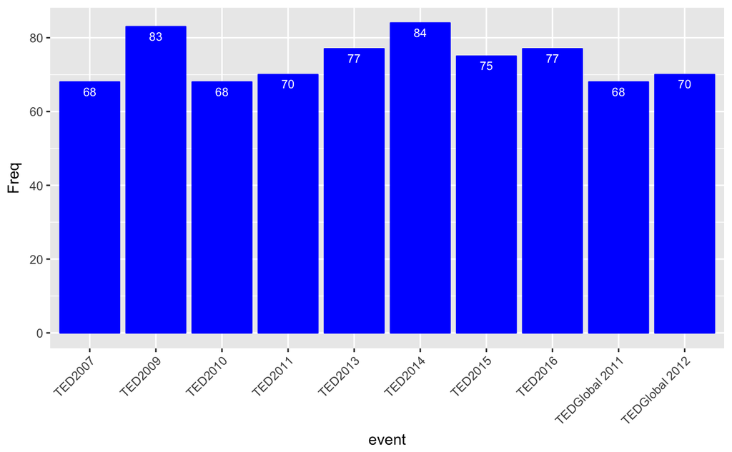

```r
events_df <- ted %>% select(c("event")) %>% group_by("event")
events_df <- as.data.frame(table(events_df))
events_df <- arrange(events_df, desc(Freq))
events_df <- head(events_df, 10)
p14 <- ggplot(data = events_df, aes(event, Freq)) +
      geom_bar(position = "dodge", stat = "identity", color = "blue", fill="blue") +
      geom_text(aes(label = Freq), vjust = 1.6, color = "white", size = 3) +
      tilt_theme
p14
```

As expected, the official TED events held the major share of TED Talks published on the TED.com platform. TED2014 had the most number of talks followed by TED2009. There isn’t too much insight to be gained from this.

TED Languages One remarkable aspect of TED Talks is the sheer number of languages in which it is accessible. Let us perform some very basic data visualisation and descriptive statistics about languages at TED.

```r
describe(ted$languages)
```

```
ted$languages
       n  missing distinct     Info     Mean      Gmd      .05      .10      .25      .50      .75      .90      .95
    2550        0       66    0.998    27.33    10.11        7       18       23       28       33       38       41

lowest :  0  1  2  3  4, highest: 64 65 66 69 72
```

On average, a TED Talk is available in 27 different languages. The maximum number of languages a TED Talk is available in is a staggering 72. Let us check which talk this is.

```r
filter(ted, ted$languages == 72)
```

| comments | description | duration | event | film_date | languages | main_speaker | name | num_speaker | published_date | ratings | related_talks | speaker_occupation | tags | title | url | views | dis_quo | filming_month | filming_year | film_weekday |
| --- | --- | --- | --- | --- | --- | --- | --- | --- | --- | --- | --- | --- | --- | --- | --- | --- | --- | --- | --- | --- |
| 736 | Is there something you've always meant to do, wanted to do, but just ... haven't? Matt Cutts suggests: Try it for 30 days. This short, lighthearted talk offers a neat way to think about setting and ac… | 207 | TED2011 | 2011-03-03 | 72 | Matt Cutts | Matt Cutts: Try something new for 30 days | 1 | 2011-07-02 | [{'id': 10, 'name': 'Inspiring', 'count': 6171}, {'id': 24, 'name': 'Persuasive', 'count': 1977}, {'id': 7, 'name': 'Funny', 'count': 1427}, {'id': 9, 'name': 'Ingenious', 'count': 386}, {'id': 3, 'na… | [{'id': 947, 'hero': 'https://pe.tedcdn.com/images/ted/195575_800x600.jpg', 'speaker': 'Derek Sivers', 'title': 'Keep your goals to yourself', 'duration': 195, 'slug': 'derek_sivers_keep_your_goals_to… | Technologist | ['culture', 'success'] | Try something new for 30 days | https://www.ted.com/talks/matt_cutts_try_something_new_for_30_days\n | 8838874 | 8.326852e-05 | 3 | 2011 | Thursday |

The most translated TED Talk of all time is Matt Cutts’ Try Something New in 30 Days. The talk does have a very universal theme of exploration. The sheer number of languages it’s available in demands a little more inspection though as it has just over 8 million views, far fewer than the most popular TED Talks.

Finally, let us check if there is a correlation between the number of views and the number of languages a talk is availbale in. We would think that this should be the case since the talk is more accessible to a larger number of people but as Matt Cutts’ talk shows, it may not really be the case.

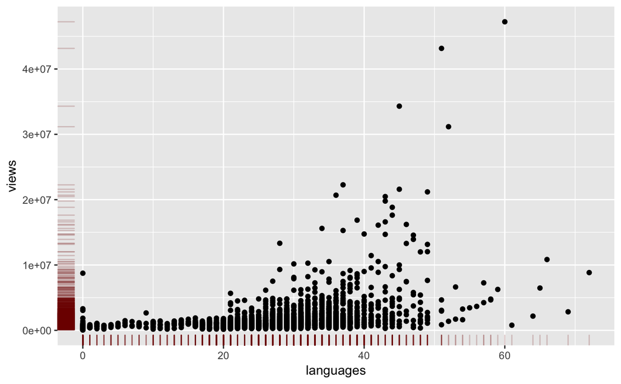

```r
scatter2 <- qplot(languages, views, data=ted)  +
         scale_y_continuous(limits=c(min(ted$views),max(ted$views))) +
         scale_x_continuous(limits=c(min(ted$languages),max(ted$languages))) +
         geom_rug(col=rgb(.5,0,0,alpha=.2))
scatter2
```

```r
cor(ted$languages, ted$views)
```

```
[1] 0.3776231
```

The Pearson coefficient is 0.38 suggesting a medium correlation between the aforementioned quantities.

TED Themes In this section, we will try to find out the most popular themes in the TED conferences. Although TED started out as a conference about technology, entertainment and design, it has since diversified into virtually every field of study and walk of life. It will be interesting to see if this conference with Silicon Valley origins has a bias towards certain topics.

To answer this question, we need to wrangle our data in a way that it is suitable for analysis. More specifically, we need to split the related_tags list into separate rows.

```r
perfect_tag <- function(x){
  x <- unlist(strsplit(x, "'"))
  val = x[2]
  for (i in 3:length(x))
    if (nchar(x[i]) >2)
      val <- c(val, x[i])
    return (val)

}
ted$processed_tags <-  lapply(ted$tags, perfect_tag)
```

```r
processed_tags <- ted$processed_tags
length(processed_tags)
```

```
[1] 2550
```

```r
processed_tags <- unlist(processed_tags, recursive=FALSE)
length(processed_tags)
```

```
[1] 19154
```

```r
processed_tags <- as.data.frame(table(processed_tags))
processed_tags <- arrange(processed_tags, desc(Freq))
head(processed_tags, 10)
```

|  | processed_tags | Freq |
| --- | --- | --- |
| 1 | technology | 727 |
| 2 | science | 567 |
| 3 | global issues | 501 |
| 4 | culture | 486 |
| 5 | TEDx | 450 |
| 6 | design | 418 |
| 7 | business | 348 |
| 8 | entertainment | 299 |
| 9 | health | 236 |
| 10 | innovation | 229 |

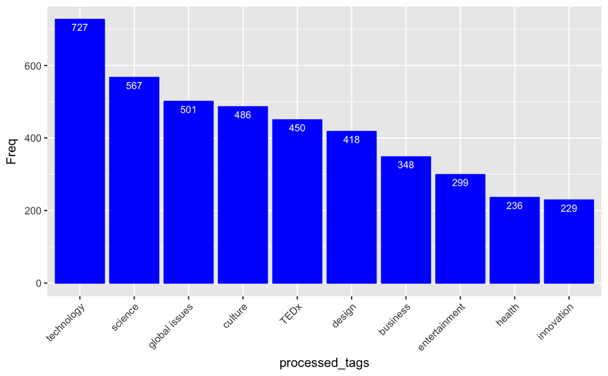

```r
processed_tags$processed_tags <- as.character(processed_tags$processed_tags)
processed_tags$processed_tags <- factor(processed_tags$processed_tags, levels=processed_tags$processed_tags)
p15 <- ggplot(data = head(processed_tags, 10), aes(processed_tags, Freq)) +
      geom_bar(position = "dodge", stat = "identity", color = "blue", fill="blue") +
      geom_text(aes(label = Freq), vjust = 1.6, color = "white", size = 3) +
      tilt_theme
p15
```

As may have been expected, Technology is the most popular topic for talks. The other two original factions, Design and Entertainment, also make it to the list of top 10 themes. Science and Global Issues are the second and the third most popular themes respectively.

The next question I want to answer is the trends in the share of topics of TED Talks across the world. Has the demand for Technology talks increased? Do certain years have a disproportionate share of talks related to global issues? Let’s find out!

```r
factor_fn <- function(x){
  return(factor(x, levels = x))
}
ted$processed_tags <- lapply(ted$processed_tags, unlist, recursive = FALSE)
ted$processed_tags <- lapply(ted$processed_tags, factor_fn)
rows_to_keep <- rep(TRUE, length(ted$processed_tags))
for (i in 1:length(ted$processed_tags)){
  if (any(unlist(ted$processed_tags[i]) %in% processed_tags$processed_tags[1:10])){
    rows_to_keep[i] <- TRUE} else {
    rows_to_keep[i] <- FALSE}
}
```

```r
pop_theme_talks <- subset(pop_theme_talks, filming_year>2008)
pop_theme_talks <- pop_theme_talks[rows_to_keep,]
```

```r
themes <- list(processed_tags$processed_tags[1:10])
themes
```

```
[[1]]
 [1] technology    science       global issues culture       TEDx          design        business      entertainment
 [9] health        innovation
416 Levels: technology science global issues culture TEDx design business entertainment health innovation ... testing
```

```r
colnames(pop_theme_talks)
```

```
 [1] "comments"           "description"        "duration"           "event"              "film_date"
 [6] "languages"          "main_speaker"       "name"               "num_speaker"        "published_date"
[11] "ratings"            "related_talks"      "speaker_occupation" "tags"               "title"
[16] "url"                "views"              "dis_quo"            "filming_month"      "filming_year"
[21] "film_weekday"       "processed_tags"
```

```r
# drop columns
pop_theme_talks <- pop_theme_talks[, c("name", "event", "views", "filming_month", "filming_year", "processed_tags")]
pop_theme_talks
```

| name | event | views | filming_month | filming_year | processed_tags |
| --- | --- | --- | --- | --- | --- |
| Jackie Tabick: The balancing act of compassion | TEDSalon 2009 Compassion | 176245 | 10 | 2009 |  |
| Dayananda Saraswati: The profound journey of compassion | Chautauqua Institution | 273396 | 10 | 2009 |  |
| James Forbes: Compassion at the dinner table | Chautauqua Institution | 204410 | 10 | 2009 |  |
| Feisal Abdul Rauf: Lose your ego, find your compassion | TEDSalon 2009 Compassion | 433202 | 10 | 2009 |  |
| Robert Thurman: Expanding your circle of compassion | Chautauqua Institution | 304800 | 10 | 2009 |  |
| Robert Wright: The evolution of compassion | TEDSalon 2009 Compassion | 236002 | 10 | 2009 |  |
| Bill Gates: Mosquitos, malaria and education | TED2009 | 2634359 | 2 | 2009 |  |
| Elizabeth Gilbert: Your elusive creative genius | TED2009 | 13155478 | 2 | 2009 |  |
| Barry Schwartz: Our loss of wisdom | TED2009 | 3303825 | 2 | 2009 |  |
| Juan Enriquez: The next species of human | TED2009 | 2954577 | 2 | 2009 |  |

[output cut: 990 more lines]

```r
x <- unlist(pop_theme_talks$processed_tags[4])
toString(x[3])
```

```
[1] "global issues"
```

```r
#tag <- "technology"
#tag <- "science"
#tag <- "global issues"
#tag <- "culture"
#tag <-  "TEDx"
#tag <- "design"
#tag <- "business"
#tag <-  "entertainment"
#tag <- "health"
#tag <- "innovation""
count_tag <- function(vec, tag){
  count <- 0
  x<- unlist(vec)
  for (i in 1:length(x)){
    if (toString(x[i]) == tag){
      count <- count+1
    }
  }
  return (count)
}
```

```r
pop_theme_talks$technology <- sapply(X = pop_theme_talks$processed_tags,FUN = count_tag, tag = "technology")
pop_theme_talks$science <- sapply(X = pop_theme_talks$processed_tags,FUN = count_tag, tag = "science")
pop_theme_talks$gi <- sapply(X = pop_theme_talks$processed_tags,FUN = count_tag, tag = "global issues")
pop_theme_talks$culture <- sapply(X = pop_theme_talks$processed_tags,FUN = count_tag, tag = "culture")
pop_theme_talks$tedx <- sapply(X = pop_theme_talks$processed_tags,FUN = count_tag, tag = "TEDx")
pop_theme_talks$design <- sapply(X = pop_theme_talks$processed_tags,FUN = count_tag, tag = "design")
pop_theme_talks$business <- sapply(X = pop_theme_talks$processed_tags,FUN = count_tag, tag = "business")
pop_theme_talks$et <- sapply(X = pop_theme_talks$processed_tags,FUN = count_tag, tag = "entertainment")
pop_theme_talks$health <- sapply(X = pop_theme_talks$processed_tags,FUN = count_tag, tag = "health")
pop_theme_talks$inno <- sapply(X = pop_theme_talks$processed_tags,FUN = count_tag, tag = "innovation")
```

```r
tag1 <- table(pop_theme_talks$filming_year, pop_theme_talks$technology)[,2]
tag2 <- table(pop_theme_talks$filming_year, pop_theme_talks$science)[,2]
tag3 <- table(pop_theme_talks$filming_year, pop_theme_talks$gi)[,2]
tag4 <- table(pop_theme_talks$filming_year, pop_theme_talks$culture)[,2]
tag5 <- table(pop_theme_talks$filming_year, pop_theme_talks$tedx)[,2]
tag6 <- table(pop_theme_talks$filming_year, pop_theme_talks$design)[,2]
tag7 <- table(pop_theme_talks$filming_year, pop_theme_talks$business)[,2]
tag8 <- table(pop_theme_talks$filming_year, pop_theme_talks$et)[,2]
tag9 <- table(pop_theme_talks$filming_year, pop_theme_talks$health)[,2]
tag10 <- table(pop_theme_talks$filming_year, pop_theme_talks$inno)[,2]
```

```r
tag_df <- cbind.data.frame(tag1, tag2, tag3, tag4, tag5, tag6, tag7, tag8, tag9, tag10)
#tag_df$filming_year <- as.numeric(rownames(tag_df))
tag_df <- as.data.frame(t(tag_df))
#colnames(tag_df) <- tag_df[1, ]
#tag_df<- tag_df[-1, ]
#tag_df$myfactor <- factor(row.names(tag_df))
tag_df
```

|  | 2009 | 2010 | 2011 | 2012 | 2013 | 2014 | 2015 | 2016 | 2017 |
| --- | --- | --- | --- | --- | --- | --- | --- | --- | --- |
| tag1 | 76 | 61 | 71 | 67 | 63 | 41 | 46 | 58 | 20 |
| tag2 | 56 | 62 | 65 | 59 | 33 | 28 | 51 | 45 | 12 |
| tag3 | 53 | 61 | 40 | 52 | 39 | 29 | 31 | 35 | 13 |
| tag4 | 39 | 63 | 62 | 46 | 51 | 17 | 16 | 12 | 0 |
| tag5 | 14 | 55 | 74 | 81 | 47 | 33 | 40 | 46 | 7 |
| tag6 | 46 | 42 | 44 | 31 | 32 | 14 | 22 | 27 | 10 |
| tag7 | 41 | 49 | 24 | 29 | 34 | 18 | 13 | 28 | 6 |
| tag8 | 27 | 36 | 29 | 22 | 21 | 7 | 10 | 10 | 3 |
| tag9 | 23 | 19 | 9 | 24 | 25 | 24 | 29 | 26 | 10 |
| tag10 | 15 | 7 | 7 | 25 | 15 | 11 | 36 | 59 | 13 |

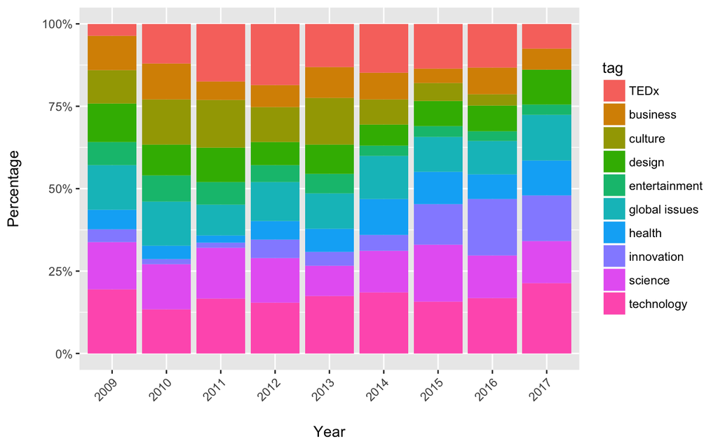

```r
library(reshape2)
library (scales)
tag_df$row <- seq_len(nrow(tag_df))
dat2 <- melt(tag_df, id.vars = "row")
dat2$tag <- rep(c("technology","science","global issues", "culture", "TEDx", "design", "business", "entertainment",
                  "health","innovation"), 9)
p16 <- ggplot(dat2, aes(x=variable, y=value, fill=tag)) +
  geom_bar(stat="identity", position = "fill") +
  xlab("\nYear") +
  ylab("Percentage\n") +
  scale_y_continuous(labels = percent_format()) +
  tilt_theme
p16
```

```r
head(dat2)
```

|  | row | variable | value | tag |
| --- | --- | --- | --- | --- |
| 1 | 1 | 2009 | 76 | technology |
| 2 | 2 | 2009 | 56 | science |
| 3 | 3 | 2009 | 53 | global issues |
| 4 | 4 | 2009 | 39 | culture |
| 5 | 5 | 2009 | 14 | TEDx |
| 6 | 6 | 2009 | 46 | design |

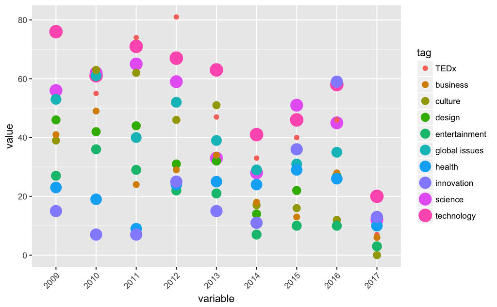

```r
p17 <- ggplot(dat2, aes(x=variable, y=value, colour=tag)) +
  geom_point(aes(x=variable, y=value, color=tag, size = tag)) +
  tilt_theme
p17
```

Talks on culture have witnessed a dip, decreasing steadily starting 2013. The share of culture talks has been the least in 2017. Entertainment talks also seem to have witnessed a slight decline in popularity since 2009.

Like with the speaker occupations, let us investigate if certain topics tend to garner more views than certain other topics. We will be doing this analysis for the top ten categories that we discovered in an earlier cell. As with the speaker occupations, the box plot will be used to deduce this relation.